# Homework 1

Ahmet Tabakoglu

14/04/2021

## Analyzing the relationship between the level of US dollars, consumer price index, and their effect on consumer confidence index in Turkey

This project aims to investigate whether the changes in consumer confidence index depend on the level of US dollar compared to Turkish Lira, and the consumer price index in Turkey. All data sets below are collected from [EVDS](https://evds2.tcmb.gov.tr/index.php?) website and include the data between March 2018 - March 2021.

### 1- Level of US dollars compared to Turkish Lira

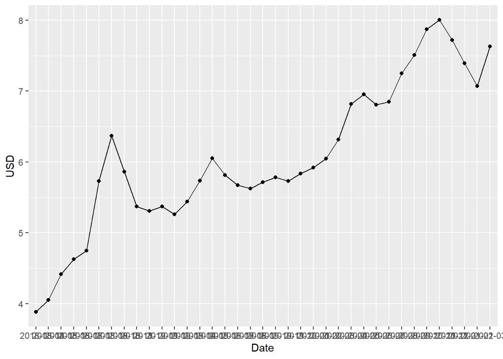

```r
library("readxl")
library(ggplot2)
usdData<-read_excel("C:\\Users\\AHMET\\Desktop\\usd.xlsx")
ggplot(data = usdData, aes(x = Date, y = USD))+
  geom_point()+
  geom_line(aes(group=1))
```

The graph above shows the changes in value of one US dollar in Turkey. It is clearly seen that there is an increasing trend. There is not any obvious quarterly or monthly similarity, however, it can be argued that value of one US dollar is more likely to increase rather than decrease over periods. The most abnormal change in data is observed during the 8th and 9th months of 2018, where there is a huge increase in two consecutive months followed by two balancing decreases. This behavior of the data set is most probably caused by the political issues of Turkey.

### 2- Consumer Price Index

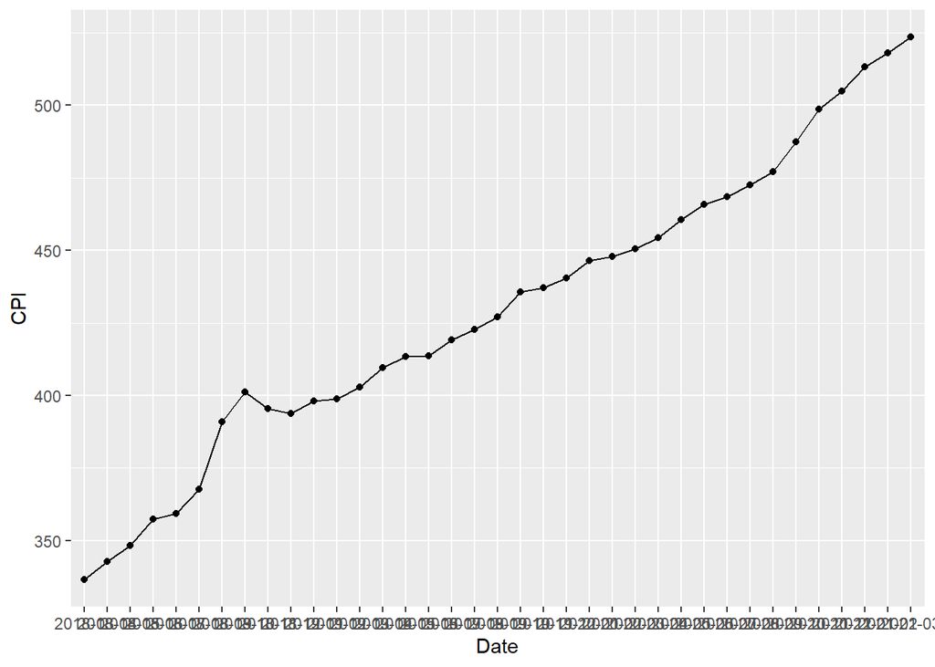

```r
cpiData<-read_excel("C:\\Users\\AHMET\\Desktop\\cpi.xlsx")
ggplot(data = cpiData, aes(x = Date, y = CPI))+
  geom_point()+
  geom_line(aes(group=1))
```

The CPI graph above has an increasing trend. Moreover, most of the data points have a similar amount of increase compared to their previous month. As mentioned in the first part, an abnormal increase is observed during 9th and 10th months of 2018, almost the same period as the unusual change happened in the US dollar. It can be claimed that the increase in value of the US dollar in this period caused CPI to increase rapidly since change in the US dollar is followed by the change in CPI immediately.

### 3- Consumer Confidence Index

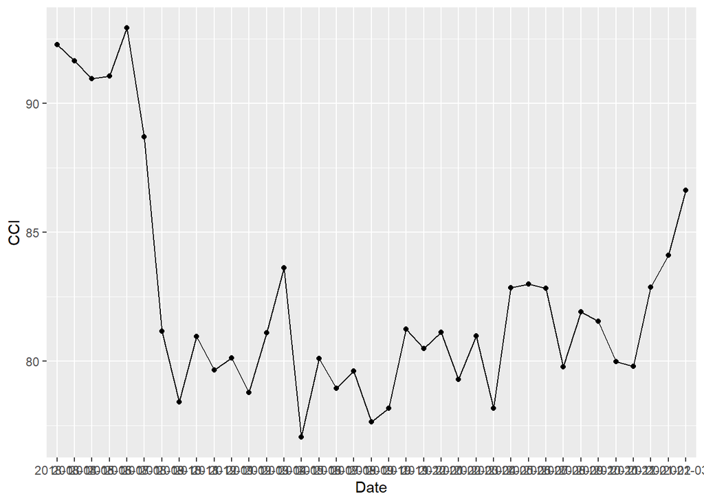

```r
cciData<-read_excel("C:\\Users\\AHMET\\Desktop\\cci.xlsx")
ggplot(data = cciData, aes(x = Date, y = CCI))+
  geom_point()+
  geom_line(aes(group=1))
```

Since CCI is based on surveys, many ups and downs are observed at first sight. Even so, this data set has a decreasing trend. As there are so many ups and downs, a similarity cannot be observed over periods. An enormous decrease welcomes us in the 8th and 9th months of 2018. This abnormal decrease can be caused by the changes in USD and CPI, or all the changes in these three parts may have the same reason.

### The Keyword

It is known that price level has an inverse relationship with purchasing power since income of households does not actually rise by the same proportion as prices do. The data sets mentioned and plotted above comparatively prove that a negative circumstance causes price level to increase, and tendency to buy to decrease. The word “zam” stands for “rise in price” and will be investigated to see if the number of searches for “zam” on Google increases or decreases based on the changes in USD, CPI, and CCI. The graph below includes the data set between March 2018 - March 2021, and all the data is collected from [Google Trends](https://trends.google.com/trends/?geo=US).

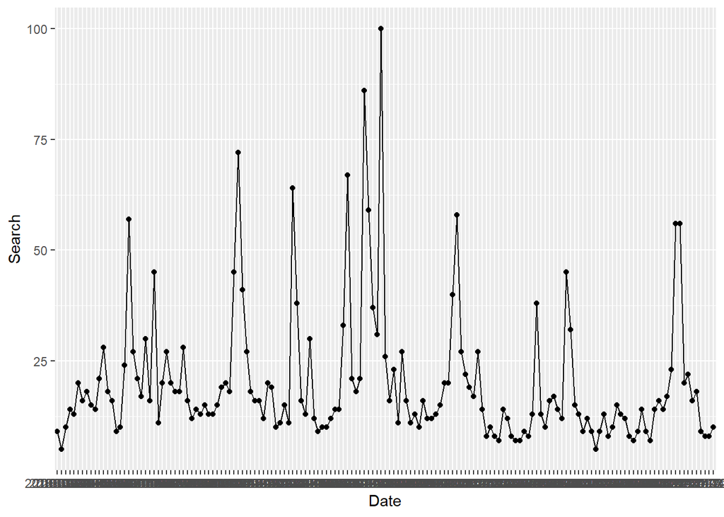

```r
zamData<-read_excel("C:\\Users\\AHMET\\Desktop\\zam.xlsx")
ggplot(data = zamData, aes(x = Date, y = Search))+
  geom_point()+
  geom_line(aes(group=1))
```

### Conclusion

When all the data sets gathered and plotted above are compared, it can be concluded that an external factor that increases the value of a foreign currency will also raise the consumer price index indirectly. Afterwards, the increased price level will end up decreasing the consumer confidence index. In other words, people will have less tendency to buy when prices increase, and it can be caused by the domino effect of an external factor. Nonetheless, when the searching trends are investigated, it is seen that there is not a certain trend over periods. There are too many ups and downs which can be caused by several reasons. If the first three data sets are considered, it can be argued that most of the peak points in searching trends are consistent with the periods that price levels have increased. However, some of the peak points are completely irrelevant with the changes in price level. These points can be explained with untimely price increases or rumors on some highly consumed goods.